# Session 5: Regression Discontinuity Design

When Arbitrary Cutoffs Create Natural Experiments

## Introduction

Two students take the same exam. One scores 89, the other scores 90. The school awards a scholarship to everyone who scores 90 or above. Are these two students fundamentally different? Almost certainly not — they’re practically identical. But one gets the scholarship and the other doesn’t.

This is the core intuition behind **Regression Discontinuity Design (RDD)**: when treatment is assigned by whether a continuous variable crosses a **cutoff**, units just above and just below that cutoff are effectively randomly assigned. The cutoff creates a **local experiment**.

### Key Vocabulary

| Term | Meaning |
| --- | --- |
| **Running variable** | The continuous variable that determines treatment (exam score, age, vote margin) |
| **Cutoff / threshold** | The value of the running variable where treatment switches on |
| **Treatment** | What happens when you cross the cutoff (scholarship, legal drinking, incumbency) |
| **LATE** | Local Average Treatment Effect — the effect *at the cutoff*, not everywhere |
| **Bandwidth** | How far from the cutoff we look when estimating |

### Where RDD Fits

We’ve now seen several approaches to causal inference:

- **Matching** (Session 2): find similar treated/control units based on observables
- **Difference-in-Differences** (Session 3): exploit timing of treatment with parallel trends
- **Synthetic Control** (Session 4): construct a weighted counterfactual from donor units
- **RDD** (today): exploit an arbitrary cutoff that creates near-random assignment

RDD is sometimes called the most **credible** quasi-experimental design because near the cutoff, treatment assignment is essentially random.

```r
rm(list = ls())
library(ggplot2)
library(kableExtra)
library(rdrobust)
library(rddensity)
library(masteringmetrics)
```

## 1. Build Intuition with Simulation

Before touching real data, let’s build RDD from scratch with simulated data. This is the only way to truly understand what’s happening — we **know** the true treatment effect because we created it.

### 1.1 The Simplest Case: Linear Data with a Jump

```r
set.seed(42)
n <- 500

# Running variable: uniformly distributed between -1 and 1
X <- runif(n, -1, 1)

# Treatment: you get treated if X >= 0
W <- as.integer(X >= 0)

# True treatment effect
tau <- 3

# Outcome: linear in X, with a jump of size tau at the cutoff
Y <- 1 + 2 * X + tau * W + rnorm(n, sd = 1)

sim_data <- data.frame(X = X, W = W, Y = Y)
```

The data-generating process is:

$$Y_i = 1 + 2X_i + 3 \cdot W_i +
\varepsilon_i, \quad W_i = \mathbf{1}(X_i \geq 0)$$

We **know** the true effect is $\tau = 3$. Can we recover it?

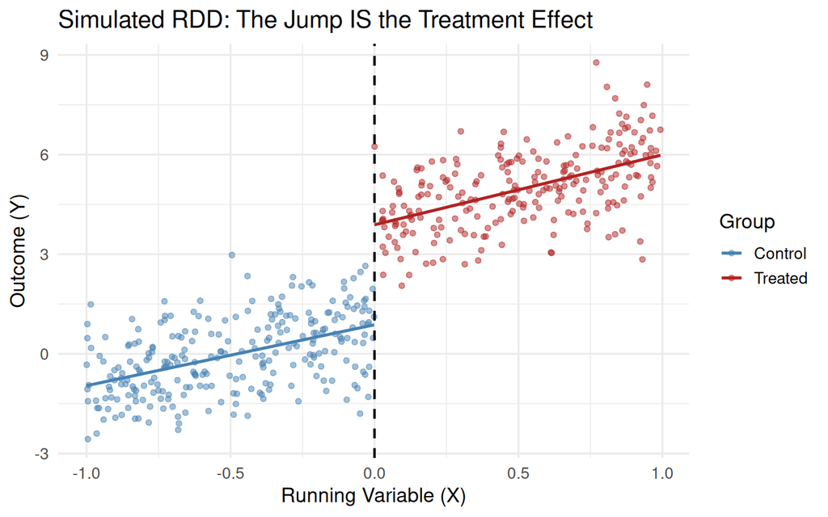

```r
ggplot(sim_data, aes(x = X, y = Y, color = factor(W))) +
  geom_point(alpha = 0.5) +
  geom_vline(xintercept = 0, linetype = "dashed", linewidth = 0.8) +
  geom_smooth(method = "lm", se = FALSE) +
  scale_color_manual(values = c("steelblue", "firebrick"), labels = c("Control", "Treated")) +
  labs(x = "Running Variable (X)", y = "Outcome (Y)",
       title = "Simulated RDD: The Jump IS the Treatment Effect",
       color = "Group") +
  theme_minimal(base_size = 14)
```

The jump at $X = 0$ is clearly visible. Now let’s estimate it with ordinary regression:

```r
m_linear <- lm(Y ~ X + W, data = sim_data)
summary(m_linear)
```

```
##
## Call:
## lm(formula = Y ~ X + W, data = sim_data)
##
## Residuals:
##     Min      1Q  Median      3Q     Max
## -2.9420 -0.6262  0.0066  0.6888  3.2986
##
## Coefficients:
##             Estimate Std. Error t value Pr(>|t|)
## (Intercept)  0.93864    0.09506   9.874   <2e-16 ***
## X            1.96007    0.14806  13.238   <2e-16 ***
## W            3.02255    0.17371  17.400   <2e-16 ***
## ---
## Signif. codes:  0 '***' 0.001 '**' 0.01 '*' 0.05 '.' 0.1 ' ' 1
##
## Residual standard error: 0.9815 on 497 degrees of freedom
## Multiple R-squared:  0.8729, Adjusted R-squared:  0.8724
## F-statistic:  1707 on 2 and 497 DF,  p-value: < 2.2e-16
```

The coefficient on `W` should be close to 3. In a linear world, plain OLS with the running variable as a control works perfectly.

**Why does this work?** We’re comparing units just above and just below the cutoff, controlling for the underlying trend in X. The coefficient on W captures the **discontinuous jump** — exactly what we want.

### 1.2 When Linearity Fails: The Nonlinear Case

Real-world relationships are rarely perfectly linear. What happens when there’s serious curvature? Let’s generate new data with a strongly nonlinear relationship:

```r
# Generate fresh data with a nonlinear DGP
set.seed(314)
n <- 500
X <- runif(n, -1, 1)
W <- as.integer(X >= 0)
tau <- 3

# The true function: quadratic (U-shape) + cubic (asymmetry)
# f(x) = 3 + 15x² - 8x³
# The quadratic creates a U-shape; the cubic makes the left arm steeper
Y_nl <- 3 + 15 * X^2 - 8 * X^3 + tau * W + rnorm(n, sd = 2)

sim_nl <- data.frame(X = X, W = W, Y = Y_nl)
```

$$Y_i = 3 + 15X_i^2 - 8X_i^3 + 3 \cdot W_i
+ \varepsilon_i$$

Still $\tau = 3$. But the underlying relationship is now a U-shape: high at the edges, low near the cutoff. Let’s see what this looks like:

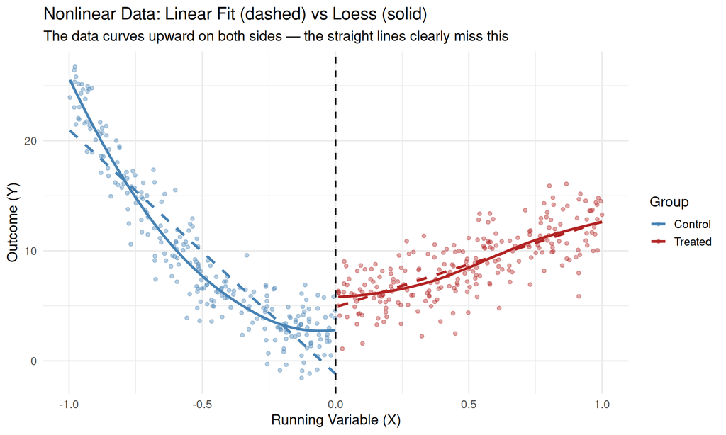

```r
ggplot(sim_nl, aes(x = X, y = Y, color = factor(W))) +
  geom_point(alpha = 0.4, size = 1.5) +
  geom_vline(xintercept = 0, linetype = "dashed", linewidth = 0.8) +
  geom_smooth(method = "lm", se = FALSE, linetype = "dashed", linewidth = 1.2) +
  geom_smooth(method = "loess", se = FALSE, linewidth = 1.2) +
  scale_color_manual(values = c("steelblue", "firebrick"), labels = c("Control", "Treated")) +
  labs(x = "Running Variable (X)", y = "Outcome (Y)",
       title = "Nonlinear Data: Linear Fit (dashed) vs Loess (solid)",
       subtitle = "The data curves upward on both sides — the straight lines clearly miss this",
       color = "Group") +
  theme_minimal(base_size = 14)
```

Both sides of the data curve upward away from the cutoff — a U-shape. The dashed linear fits slice through this curve in a straight line, obviously missing the shape of the data. What does this do to our treatment effect estimate?

```r
m_naive <- lm(Y ~ X + W, data = sim_nl)
summary(m_naive)
```

```
##
## Call:
## lm(formula = Y ~ X + W, data = sim_nl)
##
## Residuals:
##     Min      1Q  Median      3Q     Max
## -11.228  -3.865  -1.052   3.642  13.374
##
## Coefficients:
##             Estimate Std. Error t value Pr(>|t|)
## (Intercept)   5.7982     0.4859  11.934  < 2e-16 ***
## X            -7.7107     0.7691 -10.026  < 2e-16 ***
## W             6.7284     0.8731   7.706  7.1e-14 ***
## ---
## Signif. codes:  0 '***' 0.001 '**' 0.01 '*' 0.05 '.' 0.1 ' ' 1
##
## Residual standard error: 4.985 on 497 degrees of freedom
## Multiple R-squared:  0.1727, Adjusted R-squared:  0.1693
## F-statistic: 51.86 on 2 and 497 DF,  p-value: < 2.2e-16
```

The coefficient on `W` is about **6.7** — more than double the true effect of 3. The linear model is massively biased.

#### Why Is the Bias Positive?

The linear model cannot capture the curvature, so it absorbs the curvature into the treatment effect. Here’s the intuition:

The data forms a U-shape — observations far from the cutoff sit much higher than observations near the cutoff. On the **control side** (left), the data curves steeply upward as you move away from 0 (the cubic term reinforces the quadratic for $X < 0$). On the **treated side** (right), the data also curves up, but more gently (the cubic term works against the quadratic for $X > 0$).

When we force a straight line through the control side, it has to accommodate those high-sitting points far from the cutoff. The line gets pulled upward by them, and at the cutoff ($X = 0$) it **undershoots** the true value. The same happens on the treated side, but less severely (gentler curvature). The net result: the gap between the two lines at the cutoff is **larger** than the true jump. The model mistakes curvature for treatment effect.

### 1.3 Fix 1: Add Polynomial Terms

If the problem is that a straight line can’t capture the curvature, the obvious fix is to model the curvature explicitly:

```r
m_poly <- lm(Y ~ X + I(X^2) + I(X^3) + W, data = sim_nl)
summary(m_poly)
```

```
##
## Call:
## lm(formula = Y ~ X + I(X^2) + I(X^3) + W, data = sim_nl)
##
## Residuals:
##     Min      1Q  Median      3Q     Max
## -6.3560 -1.2776  0.0904  1.3108  5.4591
##
## Coefficients:
##             Estimate Std. Error t value Pr(>|t|)
## (Intercept)   2.6311     0.2580  10.197  < 2e-16 ***
## X            -0.4580     0.7512  -0.610    0.542
## I(X^2)       15.1348     0.2976  50.849  < 2e-16 ***
## I(X^3)       -7.7233     0.7693 -10.040  < 2e-16 ***
## W             3.2681     0.4582   7.132 3.53e-12 ***
## ---
## Signif. codes:  0 '***' 0.001 '**' 0.01 '*' 0.05 '.' 0.1 ' ' 1
##
## Residual standard error: 1.98 on 495 degrees of freedom
## Multiple R-squared:  0.8701, Adjusted R-squared:  0.869
## F-statistic: 828.8 on 4 and 495 DF,  p-value: < 2.2e-16
```

The coefficient on `W` is now close to 3 (true value). Let’s compare the two models (recall that the naive linear model estimated $\hat{\tau} \approx 6.7$):

```r
comp <- data.frame(
  Model = c("Linear: Y ~ X + W",
            "Polynomial: Y ~ X + X² + X³ + W"),
  Estimate = c(round(coef(m_naive)["W"], 2),
               round(coef(m_poly)["W"], 2)),
  SE = c(round(summary(m_naive)$coefficients["W", "Std. Error"], 2),
         round(summary(m_poly)$coefficients["W", "Std. Error"], 2)),
  Bias = c(round(coef(m_naive)["W"] - tau, 2),
           round(coef(m_poly)["W"] - tau, 2)),
  R_squared = c(round(summary(m_naive)$r.squared, 3),
                round(summary(m_poly)$r.squared, 3))
)

kable(comp, col.names = c("Model", "Estimate of τ", "Std. Error", "Bias (vs true τ=3)", "R²"),
      caption = "Naive Linear vs Polynomial Model") %>%
  kable_styling(bootstrap_options = c("striped", "hover"), full_width = FALSE)
```

Naive Linear vs Polynomial Model

| Model | Estimate of τ | Std. Error | Bias (vs true τ=3) | R² |
| --- | --- | --- | --- | --- |
| Linear: Y ~ X + W | 6.73 | 0.87 | 3.73 | 0.173 |
| Polynomial: Y ~ X + X² + X³ + W | 3.27 | 0.46 | 0.27 | 0.870 |

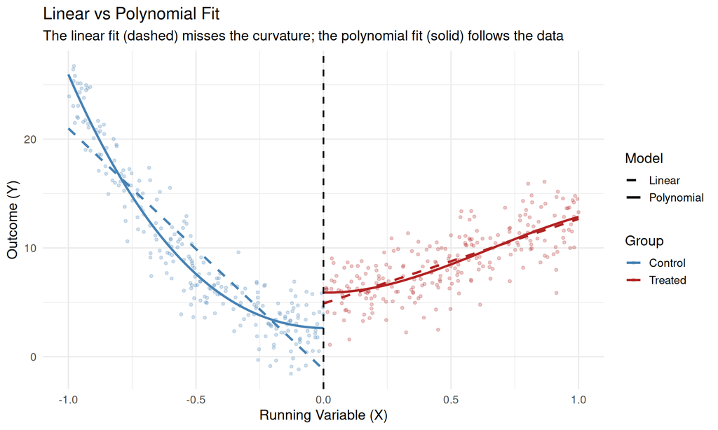

```r
# Visual comparison: fitted lines from both models
# For the linear fit, we fit SEPARATE lines on each side (as geom_smooth does)
X_grid_ctrl <- seq(-1, 0, length.out = 200)
X_grid_trt  <- seq(0, 1, length.out = 200)

# Separate linear fits on each side
m_lin_ctrl <- lm(Y ~ X, data = sim_nl[sim_nl$W == 0, ])
m_lin_trt  <- lm(Y ~ X, data = sim_nl[sim_nl$W == 1, ])

pred_lin_ctrl  <- predict(m_lin_ctrl, newdata = data.frame(X = X_grid_ctrl))
pred_lin_trt   <- predict(m_lin_trt, newdata = data.frame(X = X_grid_trt))

# Polynomial predictions
pred_poly_ctrl <- predict(m_poly, newdata = data.frame(X = X_grid_ctrl, W = 0))
pred_poly_trt  <- predict(m_poly, newdata = data.frame(X = X_grid_trt, W = 1))

fit_lines <- rbind(
  data.frame(X = X_grid_ctrl, Y = pred_lin_ctrl, model = "Linear", side = "Control"),
  data.frame(X = X_grid_trt, Y = pred_lin_trt, model = "Linear", side = "Treated"),
  data.frame(X = X_grid_ctrl, Y = pred_poly_ctrl, model = "Polynomial", side = "Control"),
  data.frame(X = X_grid_trt, Y = pred_poly_trt, model = "Polynomial", side = "Treated")
)

ggplot() +
  geom_point(data = sim_nl, aes(x = X, y = Y,
             color = ifelse(W == 1, "Treated", "Control")),
             alpha = 0.25, size = 1.2) +
  geom_line(data = fit_lines, aes(x = X, y = Y, color = side, linetype = model),
            linewidth = 1.1) +
  geom_vline(xintercept = 0, linetype = "dashed", linewidth = 0.8) +
  scale_color_manual(values = c("Control" = "steelblue", "Treated" = "firebrick")) +
  scale_linetype_manual(values = c("Linear" = "dashed", "Polynomial" = "solid")) +
  labs(x = "Running Variable (X)", y = "Outcome (Y)",
       title = "Linear vs Polynomial Fit",
       subtitle = "The linear fit (dashed) misses the curvature; the polynomial fit (solid) follows the data",
       color = "Group", linetype = "Model") +
  theme_minimal(base_size = 14)
```

The polynomial captures the curvature and recovers the true jump at the cutoff. But we had to **guess** the correct functional form (cubic). In real data, we don’t know the true form, and high-order polynomials can produce wild behavior at the boundaries (**Runge’s phenomenon**).

#### What Is the Treatment Effect When the Slopes Are Different?

Look at the dashed lines above. The control side slopes *downward*, the treated side slopes *upward*. The entire trend changes direction at the cutoff. So what exactly is the “treatment effect”?

The treatment effect in RDD is always the **vertical gap between the two curves right at the cutoff** — the jump at $X = 0$. It is *not* about the slopes. The slopes can be completely different on the two sides, and that’s fine. What we’re measuring is: if I’m standing right at the cutoff, how much does the outcome jump when I cross from control to treated?

This means our model should allow different slopes on each side. The proper specification is:

$$Y_i = \alpha + \beta_1 X_i + \gamma W_i
+ \beta_2 (W_i \times X_i) + \varepsilon_i$$

The interaction term $W_i \times X_i$ lets each side have its own slope. The coefficient $\gamma$ captures the **jump** at $X = 0$ — our treatment effect — while $\beta_2$ captures how much the slope changes. This is equivalent to fitting separate regressions on each side. In practice, `rdrobust` always allows different slopes — it never forces them to be equal.

```r
# Model allowing different slopes on each side
m_interact <- lm(Y ~ X + W + X:W, data = sim_nl)

cat("Model: Y ~ X + W + X:W (different slopes allowed)\n")
```

```
## Model: Y ~ X + W + X:W (different slopes allowed)
```

```r
cat("  Treatment effect (W):", round(coef(m_interact)["W"], 2),
    " (true:", tau, ")\n")
```

```
##   Treatment effect (W): 6.07  (true: 3 )
```

```r
cat("  Slope on control side (X):", round(coef(m_interact)["X"], 2), "\n")
```

```
##   Slope on control side (X): -22.17
```

```r
cat("  Additional slope on treated side (X:W):", round(coef(m_interact)["X:W"], 2), "\n")
```

```
##   Additional slope on treated side (X:W): 29.95
```

Even with the interaction, this model is still biased when using the full sample — because the underlying relationship is *curved*, not just differently sloped. What we really need is to zoom in.

### 1.4 Fix 2: Local Regression (The Key Idea)

Here’s a different — and ultimately better — idea. Instead of trying to model the entire curve correctly, **zoom in close enough to the cutoff that the nonlinearity doesn’t matter**.

This is a fact from calculus: any differentiable function is approximately linear in a small enough neighborhood of any point. So if we restrict our analysis to a narrow window around the cutoff, a simple linear model works even when the true relationship is nonlinear.

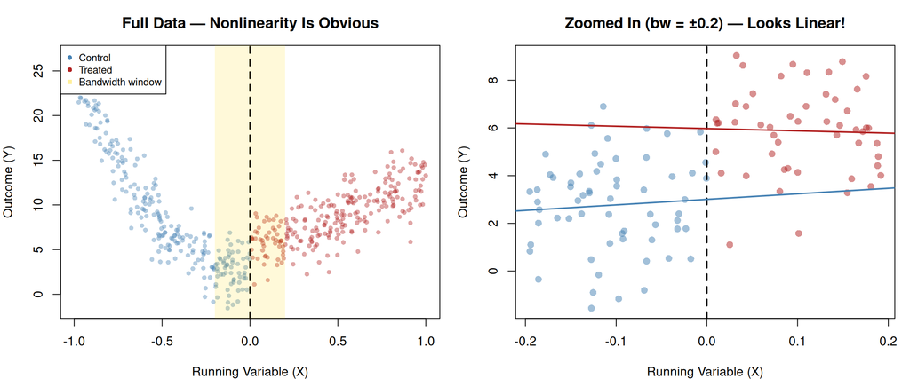

```r
bw <- 0.2  # bandwidth: only use data within ±0.2 of the cutoff
local_data <- sim_nl[abs(sim_nl$X) <= bw, ]

par(mfrow = c(1, 2), mar = c(4, 4, 3, 1))

# Left panel: full data
plot(sim_nl$X, sim_nl$Y,
     col = ifelse(sim_nl$W == 1, adjustcolor("firebrick", 0.4),
                  adjustcolor("steelblue", 0.4)),
     pch = 16, cex = 0.8,
     xlab = "Running Variable (X)", ylab = "Outcome (Y)",
     main = "Full Data — Nonlinearity Is Obvious")
abline(v = 0, lty = 2, lwd = 2)
rect(-bw, par("usr")[3], bw, par("usr")[4],
     col = adjustcolor("gold", 0.15), border = NA)
legend("topleft", legend = c("Control", "Treated", "Bandwidth window"),
       col = c("steelblue", "firebrick", adjustcolor("gold", 0.4)),
       pch = c(16, 16, 15), cex = 0.8, bg = "white")

# Right panel: zoomed into the bandwidth
plot(local_data$X, local_data$Y,
     col = ifelse(local_data$W == 1, adjustcolor("firebrick", 0.5),
                  adjustcolor("steelblue", 0.5)),
     pch = 16, cex = 1.2,
     xlab = "Running Variable (X)", ylab = "Outcome (Y)",
     main = paste0("Zoomed In (bw = ±", bw, ") — Looks Linear!"))
abline(v = 0, lty = 2, lwd = 2)

# Add linear fits to the zoomed panel
ctrl_local <- local_data[local_data$W == 0, ]
trt_local  <- local_data[local_data$W == 1, ]
if (nrow(ctrl_local) > 2) abline(lm(Y ~ X, data = ctrl_local), col = "steelblue", lwd = 2)
if (nrow(trt_local) > 2) abline(lm(Y ~ X, data = trt_local), col = "firebrick", lwd = 2)
```

Look at the right panel: once you zoom in, the data looks **linear**. The curvature that was so obvious in the full data essentially disappears in the narrow window. A simple `lm()` in this window recovers the true effect:

```r
m_local <- lm(Y ~ X + W + X:W, data = local_data)

local_result <- data.frame(
  Quantity = c("Local linear estimate (bw = ±0.2)", "True treatment effect",
               "Bias", "Observations used"),
  Value = c(round(coef(m_local)["W"], 2), tau,
            round(coef(m_local)["W"] - tau, 2),
            paste(nrow(local_data), "out of", n))
)
kable(local_result, col.names = c("", ""),
      caption = "Local Linear RDD Estimate") %>%
  kable_styling(bootstrap_options = c("striped"), full_width = FALSE)
```

Local Linear RDD Estimate

| Local linear estimate (bw = ±0.2) | 2.97 |
| --- | --- |
| True treatment effect | 3 |
| Bias | -0.03 |
| Observations used | 113 out of 500 |

### 1.5 The Fundamental Idea of RDD

Let’s pause and be explicit about what we just learned, because **this is the entire logic of RDD**:

> **RDD is, at its core, a linear regression estimated on a narrow window around a cutoff.**

That’s it. The “regression discontinuity” is just the *jump* (discontinuity) in a *regression* at the cutoff. We’re fitting two straight lines — one just below the cutoff, one just above — and measuring the gap between them at the cutoff point.

Why can we use a simple linear model? Because we’re only looking at observations **very close** to the cutoff. Close enough that any smooth nonlinear relationship is approximately linear. This is a basic result from calculus: every differentiable function looks like a straight line if you zoom in far enough (this is literally what the derivative is — the slope of the local linear approximation).

So the whole game comes down to **how close is close enough** — i.e., the **bandwidth**. And this is where the tradeoff lives:

- **Narrow bandwidth** → you’re very close to the cutoff → the linear approximation is accurate (low bias) → BUT you have very few observations → your estimate is imprecise, you lose **statistical power**, and the confidence interval is wide
- **Wide bandwidth** → you include more observations → the estimate is more precise (more statistical power, narrower CI) → BUT you’re including points far from the cutoff where the linear approximation breaks down → the estimate is biased

This is not the “variance is good” kind of variance — it’s the “we don’t have enough data to say anything with confidence” kind. With too few observations, you might get the right answer on average, but in any single sample the estimate bounces around wildly.

### 1.6 The Bias-Variance Tradeoff: Seeing It in a Table

Let’s make this concrete. We’ll estimate the treatment effect at many different bandwidths and look at how the estimate, standard error, number of observations, and statistical significance all change:

```r
bandwidths <- c(0.05, 0.10, 0.15, 0.20, 0.25, 0.30, 0.40, 0.50, 0.60, 0.80, 1.00)

bw_results <- data.frame(
  bandwidth = numeric(0),
  estimate  = numeric(0),
  se        = numeric(0),
  n_obs     = integer(0),
  p_value   = numeric(0)
)

for (h in bandwidths) {
  local <- sim_nl[abs(sim_nl$X) <= h, ]
  if (nrow(local) < 6) next
  fit <- lm(Y ~ X + W + X:W, data = local)
  s <- summary(fit)$coefficients
  bw_results <- rbind(bw_results, data.frame(
    bandwidth = h,
    estimate  = coef(fit)["W"],
    se        = s["W", "Std. Error"],
    n_obs     = nrow(local),
    p_value   = s["W", "Pr(>|t|)"]
  ))
}

# Add derived columns
bw_results$bias <- bw_results$estimate - tau
bw_results$ci_lower <- bw_results$estimate - 1.96 * bw_results$se
bw_results$ci_upper <- bw_results$estimate + 1.96 * bw_results$se
bw_results$sig <- ifelse(bw_results$p_value < 0.001, "***",
                  ifelse(bw_results$p_value < 0.01, "**",
                  ifelse(bw_results$p_value < 0.05, "*",
                  ifelse(bw_results$p_value < 0.1, ".", ""))))
bw_results$covers_truth <- ifelse(bw_results$ci_lower <= tau & bw_results$ci_upper >= tau,
                                  "Yes", "No")

# Display table
display <- data.frame(
  Bandwidth = bw_results$bandwidth,
  N = bw_results$n_obs,
  Estimate = round(bw_results$estimate, 2),
  SE = round(bw_results$se, 2),
  Bias = round(bw_results$bias, 2),
  CI = paste0("[", round(bw_results$ci_lower, 2), ", ",
              round(bw_results$ci_upper, 2), "]"),
  p = round(bw_results$p_value, 4),
  Sig = bw_results$sig,
  Covers_True = bw_results$covers_truth
)

kable(display,
      col.names = c("Bandwidth", "N obs", "Estimate", "Std Error", "Bias",
                     "95% CI", "p-value", "", "CI covers τ=3?"),
      caption = "Treatment Effect Estimates Across Bandwidths (true τ = 3)") %>%
  kable_styling(bootstrap_options = c("striped", "hover", "condensed"),
                full_width = FALSE, font_size = 13) %>%
  column_spec(5, color = ifelse(abs(bw_results$bias) > 1, "red",
                         ifelse(abs(bw_results$bias) > 0.5, "orange", "green"))) %>%
  column_spec(9, color = ifelse(bw_results$covers_truth == "No", "red", "green"))
```

Treatment Effect Estimates Across Bandwidths (true τ = 3)

Bandwidth

N obs

Estimate

Std Error

Bias

95% CI

p-value

CI covers τ=3?

0.05

25

0.97

1.69

-2.03

[-2.34, 4.27]

0.5726

Yes

0.10

51

2.17

1.06

-0.83

[0.1, 4.24]

0.0460

Yes

0.15

84

2.47

0.92

-0.53

[0.67, 4.26]

0.0087

Yes

0.20

113

2.97

0.74

-0.03

[1.51, 4.43]

0.0001

***

Yes

0.25

137

2.95

0.67

-0.05

[1.63, 4.27]

0.0000

***

Yes

0.30

160

3.01

0.63

0.01

[1.78, 4.25]

0.0000

***

Yes

0.40

200

3.64

0.55

0.64

[2.57, 4.71]

0.0000

***

Yes

0.50

254

3.70

0.46

0.70

[2.79, 4.6]

0.0000

***

Yes

0.60

319

3.81

0.45

0.81

[2.94, 4.69]

0.0000

***

Yes

0.80

403

4.59

0.42

1.59

[3.77, 5.41]

0.0000

***

No

1.00

500

6.07

0.43

3.07

[5.23, 6.91]

0.0000

***

No

Read this table carefully — it tells the entire story of RDD in one place:

- **Very narrow bandwidths** (0.05–0.10): the estimate might not even be statistically significant. With only 25–50 observations, we simply don’t have enough data to distinguish the treatment effect from noise. The standard error is huge and the p-value is high. This is the **power problem** — we’re asking too few observations to give us a precise answer.
- **Moderate bandwidths** (0.15–0.30): the sweet spot. We have enough observations for statistical significance, and we’re close enough to the cutoff that the linear approximation holds. The estimate is close to the true value of 3.
- **Wide bandwidths** (0.40–1.00): the estimate drifts **upward**, increasingly far from the truth. With the full sample (bandwidth = 1.0), we get about 6 — double the true effect! But the p-value is vanishingly small and the standard error is tight. We’re very confident in the **wrong answer**. This is the **bias problem**.

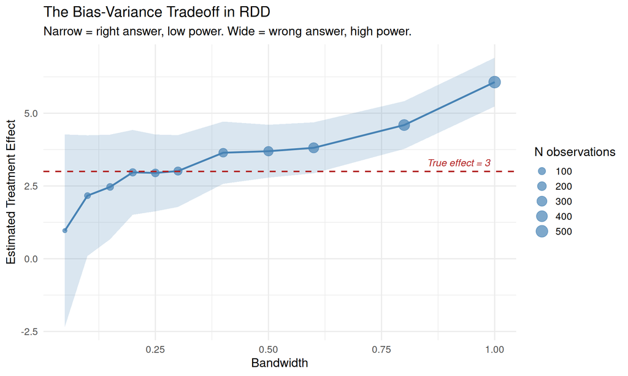

```r
ggplot(bw_results, aes(x = bandwidth, y = estimate)) +
  geom_ribbon(aes(ymin = ci_lower, ymax = ci_upper),
              alpha = 0.2, fill = "steelblue") +
  geom_line(linewidth = 1, color = "steelblue") +
  geom_point(aes(size = n_obs), color = "steelblue", alpha = 0.7) +
  geom_hline(yintercept = 3, linetype = "dashed", color = "firebrick", linewidth = 0.8) +
  annotate("text", x = 0.92, y = tau + 0.3, label = "True effect = 3",
           color = "firebrick", fontface = "italic", size = 4) +
  scale_size_continuous(range = c(2, 6), name = "N observations") +
  labs(x = "Bandwidth", y = "Estimated Treatment Effect",
       title = "The Bias-Variance Tradeoff in RDD",
       subtitle = "Narrow = right answer, low power. Wide = wrong answer, high power.") +
  theme_minimal(base_size = 14)
```

The optimal bandwidth balances these two forces. This is exactly what `rdrobust` computes automatically:

```r
rd_sim <- rdrobust(sim_nl$Y, sim_nl$X, c = 0)
```

Let’s unpack what `rdrobust` does, step by step:

```r
rdrobust_summary <- data.frame(
  Field = c("Estimation BW (h)",
            "Effective obs.",
            "Method",
            "Estimate"),
  Value = c(paste0("±", round(rd_sim$bws[1, 1], 3), " around cutoff"),
            paste0(rd_sim$N_h[1], " (left) + ", rd_sim$N_h[2],
                   " (right) = ", sum(rd_sim$N_h), " out of ", n),
            "Local linear (p = 1) on each side",
            paste0(round(rd_sim$coef[1], 2), "  (true effect = ", tau, ")"))
)

kable(rdrobust_summary, col.names = c("Field", "Value"),
      caption = "What rdrobust does") |>
  kable_styling(bootstrap_options = "striped", full_width = FALSE)
```

What rdrobust does

| Field | Value |
| --- | --- |
| Estimation BW (h) | ±0.337 around cutoff |
| Effective obs. | 92 (left) + 81 (right) = 173 out of 500 |
| Method | Local linear (p = 1) on each side |
| Estimate | 2.94 (true effect = 3) |

## 2. MLDA & Fatalities — Sharp RDD in Practice

Now let’s apply RDD to real data. The **Minimum Legal Drinking Age** (MLDA) is one of the most famous RDD applications in economics.

### 2.1 The Setting

In the US, the legal drinking age is 21. The day you turn 21, you can legally buy alcohol. **Carpenter & Dobkin (2009)** asked: does legal access to alcohol increase mortality?

**Why was this paper important?** (Background)**

This was a more open question than it sounds. Before this paper, a large body of research had exploited *historical variation* in state-level drinking ages during the 1970s-80s (when US states experimented with ages of 18, 19, and 20 before federal legislation in 1984 pushed all states to 21). Those studies almost exclusively looked at motor vehicle fatalities. A 2002 review of all published drinking age studies between 1960 and 1999 found only **six** that examined any cause of death other than traffic accidents — and those reached contradictory conclusions.

The prior studies also suffered from a serious endogeneity problem: states that lowered their drinking age were arguably different from those that didn’t, in ways related to youth drinking culture. Carpenter & Dobkin’s key innovation was to use the **current, uniform** age-21 threshold with an RDD design, sidestepping this problem entirely.

```r
data(mlda)
```

Let’s look at the raw structure first:

```r
head(mlda, 5)
```

```
## # A tibble: 5 × 19
##   agecell   all allfitted internal internalfitted external externalfitted
##     <dbl> <dbl>     <dbl>    <dbl>          <dbl>    <dbl>          <dbl>
## 1    19.1  92.8      91.7     16.6           16.7     76.2           75.0
## 2    19.2  95.1      91.9     18.3           16.9     76.8           75.0
## 3    19.2  92.1      92.0     18.9           17.1     73.2           75.0
## 4    19.3  88.4      92.2     16.1           17.3     72.3           74.9
## 5    19.4  88.7      92.3     17.4           17.4     71.3           74.9
## # ℹ 12 more variables: alcohol <dbl>, alcoholfitted <dbl>, homicide <dbl>,
## #   homicidefitted <dbl>, suicide <dbl>, suicidefitted <dbl>, mva <dbl>,
## #   mvafitted <dbl>, drugs <dbl>, drugsfitted <dbl>, externalother <dbl>,
## #   externalotherfitted <dbl>
```

```r
cat("\nColumns:", ncol(mlda), "\n")
```

```
##
## Columns: 19
```

```r
cat("Rows:", nrow(mlda), "\n")
```

```
## Rows: 50
```

The column names are cryptic — and notice there are paired columns: `all` and `allfitted`, `internal` and `internalfitted`, etc. The “fitted” columns contain smoothed values from the original paper’s regression; we’ll drop those and work with the raw rates.

**Data source** (Background)**

The data comes from the **National Center for Health Statistics** (NCHS) mortality detail files, 1997–2004 — essentially *every death certificate* in the United States. The authors obtained a confidential version with exact date of birth and date of death, allowing them to compute age at death in days. The population denominators for computing rates come from census population estimates by single year of age.

```r
# Keep only the raw (non-fitted) columns and rename for clarity
mlda <- data.frame(
  age            = mlda$agecell,
  allCauses      = mlda$all,
  internal       = mlda$internal,
  external       = mlda$external,
  alcoholRelated = mlda$alcohol,
  suicide        = mlda$suicide,
  homicide       = mlda$homicide,
  mva            = mlda$mva,
  drugs          = mlda$drugs
)

head(mlda, 3)
```

```
##        age allCauses internal external alcoholRelated  suicide homicide
## 1 19.06849  92.82540 16.61759 76.20782      0.6391380 11.20371 16.31682
## 2 19.15068  95.10074 18.32768 76.77306      0.6774093 12.19337 16.85996
## 3 19.23288  92.14429 18.91105 73.23324      0.8664426 11.71581 15.21925
##        mva    drugs
## 1 35.82933 3.872425
## 2 35.63926 3.236511
## 3 34.20565 3.202071
```

### Variable Definitions

Each value below is the **average rate per 100,000 person-years** within that age cell — not an individual count.

[output not shown]

The “should it jump?” column is our **prediction** based on the alcohol mechanism. Let’s see how the data behaves.

### 2.2 Explore the Data

```r
cat("Number of age cells:", nrow(mlda), "\n")
```

```
## Number of age cells: 50
```

```r
cat("Age range:", round(range(mlda$age), 2), "\n\n")
```

```
## Age range: 19.07 22.93
```

```r
# Summary of all death rates
death_vars <- c("allCauses", "internal", "external", "mva",
                "alcoholRelated", "suicide", "homicide", "drugs")
for (v in death_vars) {
  cat(sprintf("%-15s  min: %6.2f  max: %6.2f  mean: %6.2f\n",
              v, min(mlda[[v]], na.rm = TRUE), max(mlda[[v]], na.rm = TRUE),
              mean(mlda[[v]], na.rm = TRUE)))
}
```

```
## allCauses        min:  88.43  max: 105.27  mean:  95.67
## internal         min:  15.98  max:  24.37  mean:  20.29
## external         min:  71.34  max:  83.33  mean:  75.39
## mva              min:  26.86  max:  36.39  mean:  31.62
## alcoholRelated   min:   0.64  max:   2.52  mean:   1.26
## suicide          min:  10.89  max:  14.83  mean:  12.35
## homicide         min:  14.95  max:  18.41  mean:  16.91
## drugs            min:   3.20  max:   5.56  mean:   4.25
```

Notice the scale differences: all-cause mortality averages about 96 per 100,000, while alcohol-related deaths average only about 1.3. External causes (~75) dominate internal causes (~20). MVA (~32) and homicide (~17) are the largest single external causes. Suicide (~12) is also substantial. Drug-related deaths (~4) are relatively low in this age group.

Let’s visualize each cause of death around the cutoff:

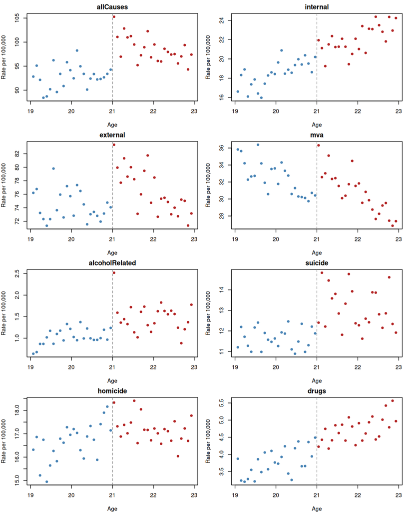

```r
par(mfrow = c(4, 2), mar = c(4, 4, 2, 1))

for (v in death_vars) {
  plot(mlda$age, mlda[[v]], pch = 19, cex = 0.8,
       xlab = "Age", ylab = "Rate per 100,000", main = v,
       col = ifelse(mlda$age >= 21, "firebrick", "steelblue"))
  abline(v = 21, lty = 2, col = "grey50")
}
```

Even in these simple plots, you can already see which causes jump at 21 (allCauses, external, mva, alcoholRelated) and which don’t (internal, homicide). Suicide and drugs are harder to read by eye — we’ll test them formally later.

### 2.3 See the Jump

Now let’s make a proper RDD plot for the main outcome. Before any regression, always **plot the data**. RDD is one of the few causal methods where the treatment effect should be visible to the naked eye.

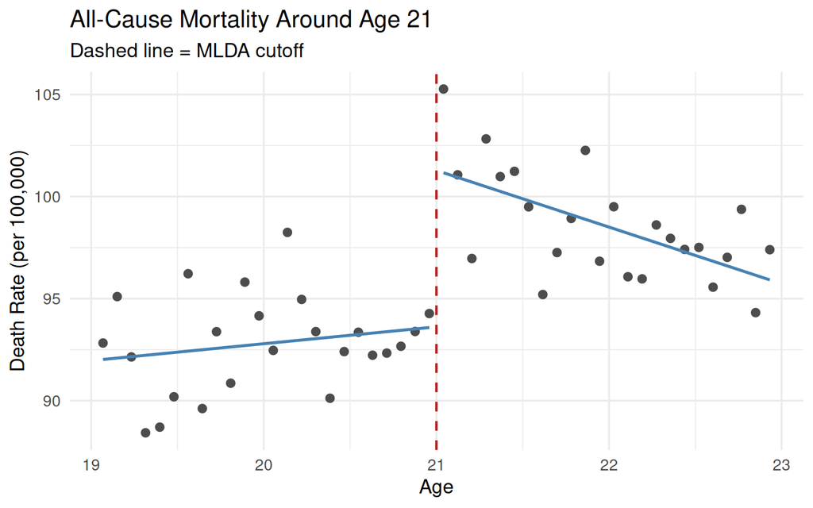

```r
ggplot(mlda, aes(x = age, y = allCauses)) +
  geom_point(size = 2.5, color = "grey30") +
  geom_vline(xintercept = 21, linetype = "dashed", color = "firebrick", linewidth = 0.8) +
  geom_smooth(data = subset(mlda, age < 21), method = "lm", se = FALSE,
              color = "steelblue", linewidth = 1) +
  geom_smooth(data = subset(mlda, age >= 21), method = "lm", se = FALSE,
              color = "steelblue", linewidth = 1) +
  labs(x = "Age", y = "Death Rate (per 100,000)",
       title = "All-Cause Mortality Around Age 21",
       subtitle = "Dashed line = MLDA cutoff") +
  theme_minimal(base_size = 14)
```

There’s a visible **jump** at 21. People just over 21 die at higher rates than people just under 21, despite being almost identical in every other way.

### 2.4 Manual Estimate with lm()

Let’s estimate this the “old-fashioned” way before using any packages. We’ll use **all 48 age cells** (no bandwidth restriction) and **center the running variable at the cutoff** (age 21) so that the intercept and treatment coefficient have clean interpretations:

```r
# Step 1: Center the running variable at the cutoff
mlda$age_centered <- mlda$age - 21

# Step 2: Treatment indicator
mlda$over21 <- ifelse(mlda$age >= 21, 1, 0)

# Step 3: Run regression with centered age and treatment indicator
m_mlda <- lm(allCauses ~ age_centered + over21, data = mlda)
summary(m_mlda)
```

```
##
## Call:
## lm(formula = allCauses ~ age_centered + over21, data = mlda)
##
## Residuals:
##     Min      1Q  Median      3Q     Max
## -5.0559 -1.8483  0.1149  1.4909  5.8043
##
## Coefficients:
##              Estimate Std. Error t value Pr(>|t|)
## (Intercept)   91.8414     0.8050 114.083  < 2e-16 ***
## age_centered  -0.9747     0.6325  -1.541     0.13
## over21         7.6627     1.4403   5.320 3.15e-06 ***
## ---
## Signif. codes:  0 '***' 0.001 '**' 0.01 '*' 0.05 '.' 0.1 ' ' 1
##
## Residual standard error: 2.493 on 45 degrees of freedom
##   (2 observations deleted due to missingness)
## Multiple R-squared:  0.5946, Adjusted R-squared:  0.5765
## F-statistic: 32.99 on 2 and 45 DF,  p-value: 1.508e-09
```

The coefficient on `over21` is our RDD estimate: **7.66 additional deaths per 100,000** at the age-21 cutoff. This is the causal effect of legal access to alcohol on mortality (under RDD assumptions). The intercept (91.84) is the predicted death rate just below the cutoff, and the age slope (-0.97) captures the background downward trend in mortality as people age through this range.

Why do we center the running variable? It makes the intercept interpretable — it becomes the predicted death rate for someone just below the cutoff. And the `over21` coefficient is the jump at exactly age 21, not at age 0.

Note that we used **all 48 age cells** in this regression — no bandwidth restriction. We’ll see shortly why that matters.

### 2.5 Allow Different Slopes on Each Side

There’s no reason the relationship between age and mortality should have the same slope below and above 21. Alcohol access could change the age-mortality gradient. Let’s allow that:

```r
m_mlda_int <- lm(allCauses ~ age_centered * over21, data = mlda)
summary(m_mlda_int)
```

```
##
## Call:
## lm(formula = allCauses ~ age_centered * over21, data = mlda)
##
## Residuals:
##    Min     1Q Median     3Q    Max
## -4.368 -1.787  0.117  1.108  5.341
##
## Coefficients:
##                     Estimate Std. Error t value Pr(>|t|)
## (Intercept)          93.6184     0.9325 100.399  < 2e-16 ***
## age_centered          0.8270     0.8189   1.010  0.31809
## over21                7.6627     1.3187   5.811  6.4e-07 ***
## age_centered:over21  -3.6034     1.1581  -3.111  0.00327 **
## ---
## Signif. codes:  0 '***' 0.001 '**' 0.01 '*' 0.05 '.' 0.1 ' ' 1
##
## Residual standard error: 2.283 on 44 degrees of freedom
##   (2 observations deleted due to missingness)
## Multiple R-squared:  0.6677, Adjusted R-squared:  0.645
## F-statistic: 29.47 on 3 and 44 DF,  p-value: 1.325e-10
```

The interaction term `age_centered:over21` is statistically significant (p = 0.003), meaning the slope **does** change at 21: mortality is rising slightly below the cutoff (slope = 0.83, not significant) but falling steeply above it (slope = 0.83 - 3.60 = -2.77). This makes sense — the initial spike in alcohol-related deaths fades as people settle into legal drinking.

But look at the treatment coefficient: `over21` is still **7.66**, exactly the same as the same-slope model. This is because we centered the running variable at the cutoff — the interaction changes the slopes on each side but doesn’t affect the estimated jump at the cutoff point itself. The SE drops from 1.44 to 1.32 because allowing different slopes gives a better fit (less residual variance), which tightens our standard errors. Compare:

```r
compare_manual <- data.frame(
  Model = c("Same slope", "Different slopes"),
  Estimate = round(c(coef(m_mlda)["over21"],
                     coef(m_mlda_int)["over21"]), 2),
  SE = round(c(summary(m_mlda)$coefficients["over21", "Std. Error"],
               summary(m_mlda_int)$coefficients["over21", "Std. Error"]), 2)
)
kable(compare_manual,
      caption = "Manual RDD Estimates: Effect of MLDA on All-Cause Mortality") |>
  kable_styling(bootstrap_options = "striped", full_width = FALSE)
```

Manual RDD Estimates: Effect of MLDA on All-Cause Mortality

| Model | Estimate | SE |
| --- | --- | --- |
| Same slope | 7.66 | 1.44 |
| Different slopes | 7.66 | 1.32 |

### 2.6 Enter rdrobust

Now let’s see what `rdrobust` does — and more importantly, **why** it does things differently.

```r
rd_mlda <- rdrobust(y = mlda$allCauses, x = mlda$age, c = 21)
summary(rd_mlda)
```

```
## Sharp RD estimates using local polynomial regression.
##
## Number of Obs.                   48
## BW type                       mserd
## Kernel                   Triangular
## VCE method                       NN
##
## Number of Obs.                   24           24
## Eff. Number of Obs.               6            6
## Order est. (p)                    1            1
## Order bias  (q)                   2            2
## BW est. (h)                   0.493        0.493
## BW bias (b)                   0.780        0.780
## rho (h/b)                     0.632        0.632
## Unique Obs.                      24           24
##
## =====================================================================
##                    Point    Robust Inference
##                 Estimate         z     P>|z|      [ 95% C.I. ]
## ---------------------------------------------------------------------
##      RD Effect     9.595     2.205     0.027     [1.077 , 18.300]
## =====================================================================
```

Let’s walk through every field in the output:

**Header section:**

[output not shown]

**Sample breakdown:**

[output not shown]

**Results table:**

The results have two parts in one row:

- **Point Estimate (9.595)**: This is the conventional RDD estimate — the jump at the cutoff from the local linear regression within the bandwidth. It’s higher than our manual estimate of 7.66 because the manual estimate used all the data (ages 19–23), including observations far from the cutoff that pull the estimate toward the overall trend. The rdrobust estimate, using only data near 21, captures the pure local jump.
- **Robust Inference (z = 2.205, p = 0.027, CI [1.077, 18.300])**: The column header in the output says “Robust Inference” — this means the z-statistic, p-value, and confidence interval have been **bias-corrected**. The point estimate (9.595) comes from a linear fit within bandwidth $h$, which is slightly biased because the true relationship is curved. The package uses the quadratic fit on the wider window $b$ to estimate and subtract that bias, then constructs CIs that account for this correction. “Robust” means the inference is honest about the bias inherent in the bandwidth choice. The CI is wide ([1.08, 18.30]) because we’re working with only 12 effective observations — that’s the price of being truly local.

So in short: `rdrobust` does exactly what we did manually — fit a linear regression near the cutoff — but it (1) chooses the bandwidth optimally, (2) weights observations by distance from the cutoff, and (3) corrects for the remaining bias using a higher-order polynomial on a wider window.

How does `rdrobust` compare to our manual estimate?

```r
# Collect all estimates into one table
est1 <- coef(m_mlda)["over21"]
se1  <- summary(m_mlda)$coefficients["over21", "Std. Error"]
est2 <- coef(m_mlda_int)["over21"]
se2  <- summary(m_mlda_int)$coefficients["over21", "Std. Error"]
est3 <- rd_mlda$coef[1]
se3  <- rd_mlda$se[3]  # robust SE

compare_all <- data.frame(
  Method = c("Manual (all data, same slope)",
             "Manual (all data, different slopes)",
             "rdrobust (optimal bandwidth)"),
  Estimate  = round(c(est1, est2, est3), 2),
  SE        = round(c(se1, se2, se3), 2),
  CI_Lower  = round(c(est1 - 1.96*se1, est2 - 1.96*se2, rd_mlda$ci[3, 1]), 2),
  CI_Upper  = round(c(est1 + 1.96*se1, est2 + 1.96*se2, rd_mlda$ci[3, 2]), 2)
)
names(compare_all)[4:5] <- c("CI Lower", "CI Upper")

kable(compare_all, caption = "All Estimates Compared") |>
  kable_styling(bootstrap_options = "striped", full_width = FALSE)
```

All Estimates Compared

| Method | Estimate | SE | CI Lower | CI Upper |
| --- | --- | --- | --- | --- |
| Manual (all data, same slope) | 7.66 | 1.44 | 4.84 | 10.49 |
| Manual (all data, different slopes) | 7.66 | 1.32 | 5.08 | 10.25 |
| rdrobust (optimal bandwidth) | 9.60 | 4.39 | 1.08 | 18.30 |

All three methods tell a similar story: turning 21 increases the death rate by roughly 7–10 deaths per 100,000. Carpenter & Dobkin report this as approximately a **9% increase in overall mortality** — a striking number for what is essentially a change in legal status.

### 2.7 Falsification: What Should NOT Jump?

A good RDD demands falsification tests. If turning 21 increases mortality **because of alcohol**, then:

- **Motor vehicle accident (MVA) deaths should jump** (drunk driving)
- **Alcohol-related deaths should jump** (obviously)
- **Internal causes (disease) should NOT jump** (cancer doesn’t care about your birthday)
- **Homicide should NOT jump** (being able to buy beer doesn’t make others kill you)

This cause-of-death decomposition was one of the paper’s biggest contributions. Let’s see it.

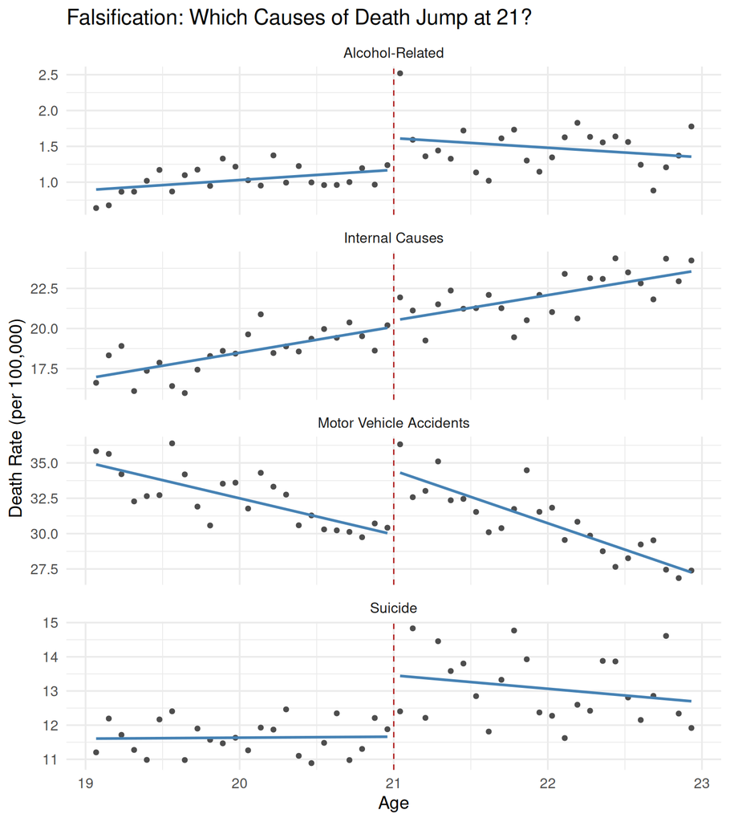

```r
# Build long-format data for faceted plot
mlda_long <- rbind(
  data.frame(age = mlda$age, death_rate = mlda$mva,
             cause = "Motor Vehicle Accidents"),
  data.frame(age = mlda$age, death_rate = mlda$internal,
             cause = "Internal Causes"),
  data.frame(age = mlda$age, death_rate = mlda$alcoholRelated,
             cause = "Alcohol-Related"),
  data.frame(age = mlda$age, death_rate = mlda$suicide,
             cause = "Suicide")
)

ggplot(mlda_long, aes(x = age, y = death_rate)) +
  geom_point(size = 1.5, color = "grey30") +
  geom_vline(xintercept = 21, linetype = "dashed", color = "firebrick") +
  geom_smooth(data = subset(mlda_long, age < 21),
              method = "lm", se = FALSE, color = "steelblue") +
  geom_smooth(data = subset(mlda_long, age >= 21),
              method = "lm", se = FALSE, color = "steelblue") +
  facet_wrap(~cause, scales = "free_y", ncol = 1) +
  labs(x = "Age", y = "Death Rate (per 100,000)",
       title = "Falsification: Which Causes of Death Jump at 21?") +
  theme_minimal(base_size = 14)
```

Now let’s quantify each cause with `rdrobust`:

```r
causes <- c("mva", "internal", "alcoholRelated", "suicide", "homicide")
cause_labels <- c("Motor Vehicle Accidents", "Internal Causes",
                  "Alcohol-Related", "Suicide", "Homicide")

# Build the table with a loop
falsification <- data.frame(
  Cause = character(0), Estimate = numeric(0),
  Robust_SE = numeric(0), Robust_p = numeric(0),
  Significant = character(0)
)

for (i in 1:length(causes)) {
  rd <- rdrobust(y = mlda[[causes[i]]], x = mlda$age, c = 21)
  falsification <- rbind(falsification, data.frame(
    Cause       = cause_labels[i],
    Estimate    = round(rd$coef[1], 3),
    Robust_SE   = round(rd$se[3], 3),
    Robust_p    = round(rd$pv[3], 3),
    Significant = ifelse(rd$pv[3] < 0.05, "Yes", "No")
  ))
}

names(falsification) <- c("Cause", "Estimate", "Robust SE", "Robust p-value", "Significant")
kable(falsification,
      caption = "Falsification: RDD Estimates by Cause of Death") |>
  kable_styling(bootstrap_options = "striped", full_width = FALSE)
```

Falsification: RDD Estimates by Cause of Death

| Cause | Estimate | Robust SE | Robust p-value | Significant |
| --- | --- | --- | --- | --- |
| Motor Vehicle Accidents | 4.903 | 2.526 | 0.060 | No |
| Internal Causes | 1.483 | 1.202 | 0.227 | No |
| Alcohol-Related | 1.062 | 0.814 | 0.144 | No |
| Suicide | 1.433 | 1.228 | 0.335 | No |
| Homicide | 0.137 | 1.057 | 0.771 | No |

## 3. Brazil Elections — RDD with `rdrobust`

Our second real-data application comes from political science: **Klašnja & Titiunik (2017)** studying the **“incumbency curse”** in Brazilian municipal elections.

### 3.1 The Setting

In the US, incumbents almost always win — over 90% of House members who run for reelection succeed. This is the **incumbency advantage**: holding office gives you name recognition, access to public funds, and the ability to implement popular policies.

In Brazil, the opposite happens. This is the puzzle Klašnja & Titiunik investigate: **why would a political party be systematically *hurt* by winning office?**

Their explanation centers on three features of Brazilian democracy:

1. **Weak parties**: Brazilian parties are among the weakest in any democracy. Over half of mayors who run again switch to a different party. Parties can’t discipline their politicians — they can’t credibly threaten to withhold future nominations or deny career advancement.
2. **Term limits**: Brazilian mayors can serve at most two consecutive terms. A second-term mayor is a *lame duck* — the party can’t motivate good behavior with the promise of reelection.
3. **The vicious cycle**: With weak parties unable to discipline lame-duck mayors, those mayors shirk (provide fewer public goods, divert resources). Voters observe this and punish the party at the next election. The punishment doesn’t fix anything — it just increases electoral volatility and makes parties even weaker.

They test this with an RDD: compare municipalities where the incumbent party **barely won** vs. **barely lost** an election. Since who wins a razor-thin election is essentially random, any difference in future performance must be *caused* by winning (and therefore holding office).

To be precise about the setup: the **incumbent party** is the party that currently holds the mayor’s office — i.e., the party that won the *previous* election. We observe how this party performs in the *current* election ($t$), and then track how it does in the *next* election ($t+1$).

**Running variable**: margin of victory at election $t$, in **percentage points** (incumbent party’s vote share minus the runner-up’s). The range is -100 to +100. A value of +5 means the incumbent party won by 5 percentage points; -5 means they lost by 5 points. A value of -100 would mean they were completely wiped out; +100 would mean they ran essentially unopposed.

**Cutoff**: 0 (the election threshold — positive margin = won, negative = lost).

**Treatment**: the incumbent party won election $t$ and therefore holds office going into election $t+1$.

**Outcome**: margin of victory at election $t+1$. Does barely winning at $t$ help or hurt at $t+1$?

The data covers **five election cycles** (2000, 2004, 2008, 2012, plus the 1996 baseline). Brazilian municipal elections happen every 4 years. The same municipality can appear in **multiple election pairs** — for example, the 2000→2004 pair and the 2004→2008 pair. Each row in the dataset is one municipality-election pair.

```r
brazil <- read.csv("CTV_2020_Sage.csv")
```

Let’s look at the raw data first:

```r
head(brazil, 5)
```

```
##   numpar_candidates_eff mv_incparty mv_incpartyfor1 party_PT_wonlag1_b1
## 1              2.403234          NA              NA                  NA
## 2              3.020916          NA              NA                  NA
## 3              3.239635          NA              NA                  NA
## 4              2.837093          NA              NA                  NA
## 5              2.567169          NA              NA                  NA
##   party_PMDB_wonlag1_b1 party_DEM_wonlag1_b1 party_PSDB_wonlag1_b1 population
## 1                    NA                   NA                    NA       6308
## 2                    NA                   NA                    NA       2918
## 3                    NA                   NA                    NA      13955
## 4                    NA                   NA                    NA       4101
## 5                    NA                   NA                    NA       2903
##   pibpc
## 1    NA
## 2    NA
## 3    NA
## 4    NA
## 5    NA
```

```r
cat("\nDimensions:", nrow(brazil), "rows x", ncol(brazil), "columns\n")
```

```
##
## Dimensions: 27455 rows x 9 columns
```

The column names are coded abbreviations from the replication files. Let’s rename them to something readable:

```r
names(brazil) <- c("effectiveParties", "margin_t", "margin_t1",
                    "wonPT_lag", "wonPMDB_lag", "wonDEM_lag", "wonPSDB_lag",
                    "population", "gdpPerCapita")
head(brazil, 3)
```

```
##   effectiveParties margin_t margin_t1 wonPT_lag wonPMDB_lag wonDEM_lag
## 1         2.403234       NA        NA        NA          NA         NA
## 2         3.020916       NA        NA        NA          NA         NA
## 3         3.239635       NA        NA        NA          NA         NA
##   wonPSDB_lag population gdpPerCapita
## 1          NA       6308           NA
## 2          NA       2918           NA
## 3          NA      13955           NA
```

### Variable Definitions

The dataset includes several covariates (party indicators, population, GDP), but for the RDD we only need the running variable, the outcome, and one covariate for a falsification check.

| Variable | Original name | What it measures |
| --- | --- | --- |
| `margin_t` | `mv_incparty` | **Running variable**: incumbent party’s margin of victory at election $t$ (percentage points). Positive = won, negative = lost. |
| `margin_t1` | `mv_incpartyfor1` | **Outcome**: incumbent party’s margin of victory at election $t+1$. |
| `gdpPerCapita` | `pibpc` | GDP per capita of the municipality (used for covariate balance check) |

### Explore the Data

```r
cat("Total observations:", nrow(brazil), "\n\n")
```

```
## Total observations: 27455
```

```r
cat("Non-missing counts for key variables:\n")
```

```
## Non-missing counts for key variables:
```

```r
key_vars <- c("margin_t", "margin_t1", "gdpPerCapita")
for (v in key_vars) {
  cat(sprintf("  %-18s  %6d  (%4.1f%%)\n",
              v, sum(!is.na(brazil[[v]])),
              100 * sum(!is.na(brazil[[v]])) / nrow(brazil)))
}
```

```
##   margin_t             13308  (48.5%)
##   margin_t1             6914  (25.2%)
##   gdpPerCapita         21948  (79.9%)
```

```r
brazil_clean <- brazil[!is.na(brazil$margin_t) & !is.na(brazil$margin_t1), ]
cat("Analysis sample (complete running variable + outcome):", nrow(brazil_clean), "rows\n")
```

```
## Analysis sample (complete running variable + outcome): 5463 rows
```

The data covers **Brazilian municipal elections from 1996–2012** (five election cycles), obtained from Brazil’s *Tribunal Superior Eleitoral* (Superior Electoral Court). Brazil has over 5,500 municipalities, and the analysis focuses on those with plurality elections (excluding cities over 200,000 voters that use a runoff system).

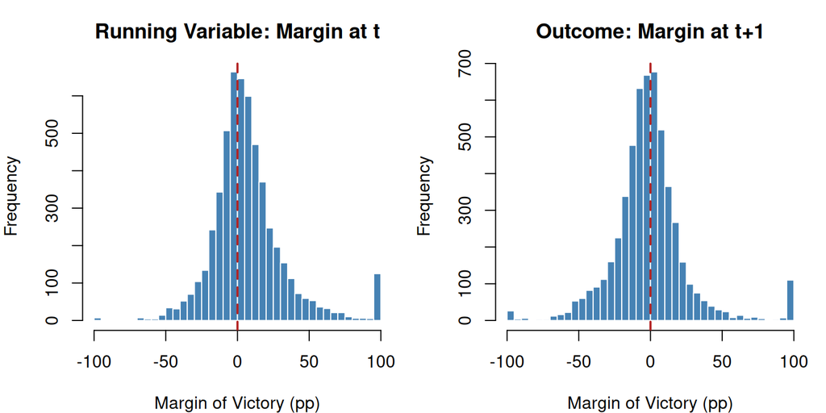

```r
par(mfrow = c(1, 2), mar = c(4, 4, 3, 1))

# Running variable distribution
hist(brazil_clean$margin_t, breaks = 50, col = "steelblue", border = "white",
     main = "Running Variable: Margin at t",
     xlab = "Margin of Victory (pp)")
abline(v = 0, col = "firebrick", lwd = 2, lty = 2)

# Outcome distribution
hist(brazil_clean$margin_t1, breaks = 50, col = "steelblue", border = "white",
     main = "Outcome: Margin at t+1",
     xlab = "Margin of Victory (pp)")
abline(v = 0, col = "firebrick", lwd = 2, lty = 2)
```

For the rest of this section, we’ll use `X` for the running variable and `Y` for the outcome — the standard notation for RDD:

```r
X <- brazil_clean$margin_t      # running variable: margin at t
Y <- brazil_clean$margin_t1     # outcome: margin at t+1

cat("Running variable (X) range:", round(range(X), 2), "\n")
```

```
## Running variable (X) range: -100 100
```

```r
cat("Outcome (Y) range:", round(range(Y), 2), "\n")
```

```
## Outcome (Y) range: -100 100
```

```r
cat("Median absolute margin:", round(median(abs(X)), 2), "pp\n")
```

```
## Median absolute margin: 11.69 pp
```

### 3.2 See the Data

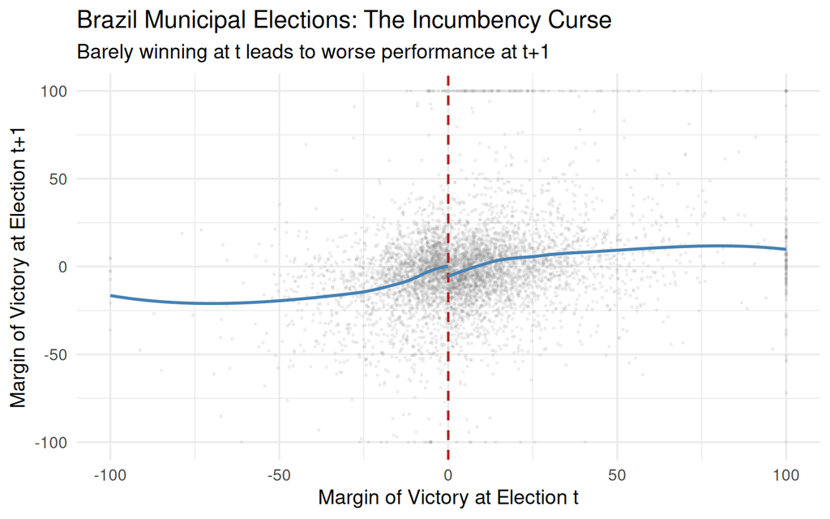

```r
ggplot(brazil_clean, aes(x = margin_t, y = margin_t1)) +
  geom_point(alpha = 0.1, size = 0.5, color = "grey50") +
  geom_vline(xintercept = 0, linetype = "dashed", color = "firebrick", linewidth = 0.8) +
  geom_smooth(data = subset(brazil_clean, margin_t < 0),
              method = "loess", se = FALSE, color = "steelblue", linewidth = 1) +
  geom_smooth(data = subset(brazil_clean, margin_t >= 0),
              method = "loess", se = FALSE, color = "steelblue", linewidth = 1) +
  labs(x = "Margin of Victory at Election t",
       y = "Margin of Victory at Election t+1",
       title = "Brazil Municipal Elections: The Incumbency Curse",
       subtitle = "Barely winning at t leads to worse performance at t+1") +
  theme_minimal(base_size = 14)
```

There’s a visible **downward jump** at the cutoff. Parties that barely won do worse in the next election compared to parties that barely lost. Incumbency is a curse, not an advantage.

### 3.3 Falsification: Is Anyone Manipulating the Cutoff?

The key RDD assumption is that no one can **precisely manipulate** their position relative to the cutoff. What would that look like here?

Remember that our running variable is defined from the **incumbent party’s perspective**: positive means the incumbent won, negative means the incumbent lost. If incumbents could manipulate close elections — through vote buying, ballot stuffing, pressuring local officials — they would push themselves from just below zero to just above zero. We’d see an asymmetry: more municipalities with a margin of +0.5 than -0.5, more at +1 than -1, and so on. The histogram of margins would have a **bump** just above zero and a **dip** just below.

This doesn’t require checking party by party. Whether the incumbent is PT, PMDB, or any other party, the running variable is always “their margin.” If incumbents *as a class* have an edge in close elections, the density of the running variable will be discontinuous at zero.

The `rddensity` function tests exactly this. It estimates the density (the histogram shape) of the running variable on each side of the cutoff separately, then asks: do the two sides meet **smoothly** at zero, or is there a gap?

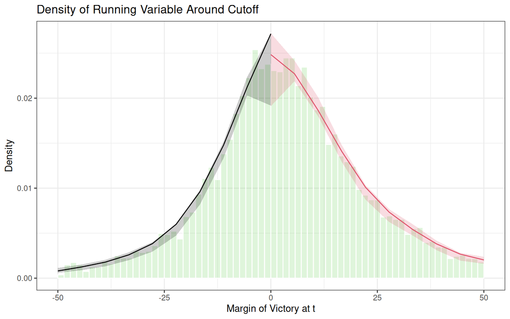

```r
dens_test <- rddensity(X)
rdplotdensity(dens_test, X,
              plotRange = c(-50, 50),
              title = "Density of Running Variable Around Cutoff",
              xlabel = "Margin of Victory at t",
              ylabel = "Density")
```

The plot shows the estimated density on each side of the cutoff (smooth curves) with confidence intervals (shaded bands). If there were manipulation, the right side would be visibly higher than the left side at the cutoff. Here, the two sides meet smoothly — no bump, no dip.

But this is the pooled test across **all** incumbent parties. What if one specific party is better at rigging close elections than others? Let’s check each of the four major parties separately. The party lag variables in the dataset tell us which party was the incumbent, so we can subset:

```r
parties <- c("wonPT_lag", "wonPMDB_lag", "wonDEM_lag", "wonPSDB_lag")
party_names <- c("PT", "PMDB", "DEM", "PSDB")

density_results <- data.frame(
  Party = character(0), N = numeric(0),
  T_stat = numeric(0), P_value = numeric(0)
)

for (i in 1:length(parties)) {
  sub <- brazil_clean[brazil_clean[[parties[i]]] == 1 &
                        !is.na(brazil_clean[[parties[i]]]), ]
  dt <- rddensity(sub$margin_t)
  density_results <- rbind(density_results, data.frame(
    Party   = party_names[i],
    N       = nrow(sub),
    T_stat  = round(dt$test$t_jk, 3),
    P_value = round(dt$test$p_jk, 3)
  ))
}

names(density_results) <- c("Incumbent Party", "N", "T-statistic", "p-value")
kable(density_results,
      caption = "Density Test by Incumbent Party") |>
  kable_styling(bootstrap_options = "striped", full_width = FALSE)
```

Density Test by Incumbent Party

| Incumbent Party | N | T-statistic | p-value |
| --- | --- | --- | --- |
| PT | 422 | 0.129 | 0.897 |
| PMDB | 1680 | -0.652 | 0.515 |
| DEM | 793 | 0.741 | 0.459 |
| PSDB | 1070 | 0.188 | 0.851 |

No party shows evidence of manipulation — all p-values are far above 0.05. PT has the fewest observations (422) and PMDB the most (1680), but regardless of sample size, the density is smooth through the cutoff for every party. No one is rigging close elections.

### 3.4 Falsification: Covariate Balance

Another check: **pre-determined covariates should NOT jump at the cutoff**. GDP per capita reflects the economic conditions of a municipality *before* the election outcome was decided. If barely-winning municipalities have systematically different GDP than barely-losing ones, that would suggest the two groups aren’t comparable — maybe richer municipalities somehow produce closer wins, or the “randomization” near the cutoff is broken.

```r
brazil_gdp <- brazil_clean[!is.na(brazil_clean$gdpPerCapita), ]

rd_gdp <- rdrobust(y = brazil_gdp$gdpPerCapita, x = brazil_gdp$margin_t, c = 0)
summary(rd_gdp)
```

```
## Sharp RD estimates using local polynomial regression.
##
## Number of Obs.                 5460
## BW type                       mserd
## Kernel                   Triangular
## VCE method                       NN
##
## Number of Obs.                 2218         3242
## Eff. Number of Obs.            1542         1751
## Order est. (p)                    1            1
## Order bias  (q)                   2            2
## BW est. (h)                  15.432       15.432
## BW bias (b)                  27.572       27.572
## rho (h/b)                     0.560        0.560
## Unique Obs.                    2211         3118
##
## =====================================================================
##                    Point    Robust Inference
##                 Estimate         z     P>|z|      [ 95% C.I. ]
## ---------------------------------------------------------------------
##      RD Effect  -361.928    -0.758     0.449 [-1790.962 , 792.461]
## =====================================================================
```

The p-value is large (0.45) — GDP per capita does **not** jump at the cutoff. Municipalities where the incumbent party barely won are economically similar to those where it barely lost. This is what we want to see.

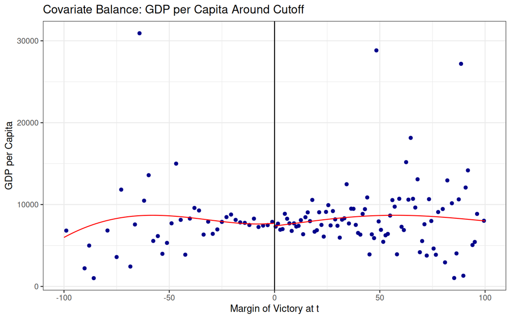

```r
rdplot(y = brazil_gdp$gdpPerCapita, x = brazil_gdp$margin_t, c = 0,
       title = "Covariate Balance: GDP per Capita Around Cutoff",
       x.label = "Margin of Victory at t",
       y.label = "GDP per Capita")
```

No visible jump. The dots (binned averages) and fitted lines meet smoothly at the cutoff. GDP is balanced.

### 3.5 Main Estimate

Now the main event: what’s the causal effect of barely winning an election on next-election performance? We pass our running variable `X` (margin at $t$) and outcome `Y` (margin at $t+1$) to `rdrobust`, with the cutoff at 0:

```r
rd_brazil <- rdrobust(Y, X, c = 0)
summary(rd_brazil)
```

```
## Sharp RD estimates using local polynomial regression.
##
## Number of Obs.                 5463
## BW type                       mserd
## Kernel                   Triangular
## VCE method                       NN
##
## Number of Obs.                 2220         3243
## Eff. Number of Obs.            1533         1740
## Order est. (p)                    1            1
## Order bias  (q)                   2            2
## BW est. (h)                  15.291       15.291
## BW bias (b)                  27.509       27.509
## rho (h/b)                     0.556        0.556
## Unique Obs.                    2213         3119
##
## =====================================================================
##                    Point    Robust Inference
##                 Estimate         z     P>|z|      [ 95% C.I. ]
## ---------------------------------------------------------------------
##      RD Effect    -6.281    -3.545     0.000   [-10.223 , -2.944]
## =====================================================================
```

The estimate is **negative** (about -6.3 percentage points): barely winning at $t$ causes a **decrease** in vote margin at $t+1$. The incumbency curse is real — holding office hurts the party’s future performance.

Klašnja & Titiunik also studied five additional Latin American countries and found a striking pattern: **the incumbency curse only appears in countries with term limits** (Mexico, Colombia). In Peru and Chile, which allow indefinite reelection, the effect disappears. This strongly supports their theory that the curse comes from the combination of weak parties and term limits, not from something specific to Brazil.

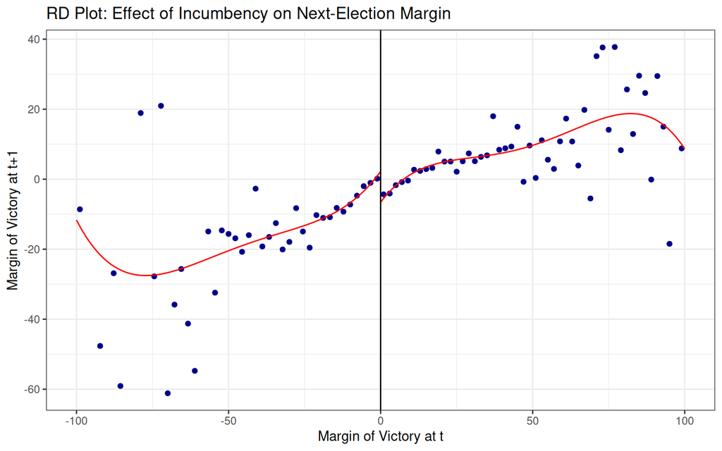

```r
rdplot(Y, X, c = 0,
       title = "RD Plot: Effect of Incumbency on Next-Election Margin",
       x.label = "Margin of Victory at t",
       y.label = "Margin of Victory at t+1")
```

How to read this plot: `rdplot` takes the raw scatterplot (thousands of points) and makes it readable. It divides the running variable into evenly-spaced **bins**, computes the **average outcome** within each bin (the dots), and fits a polynomial on each side of the cutoff (the smooth lines). The **jump** between the two fitted lines at the cutoff is the treatment effect. Here, the line on the right starts clearly lower than where the line on the left ends — the incumbency curse is visible.

### 3.6 Manual Estimate for Comparison

Let’s do this with plain `lm()` to see how bandwidth matters. We’ll try two approaches: using all the data, and restricting to a narrow window around the cutoff ($\pm 20$ percentage points).

```r
brazil_clean$won <- ifelse(brazil_clean$margin_t >= 0, 1, 0)

# Full data, linear
m_brazil_full <- lm(margin_t1 ~ margin_t + won, data = brazil_clean)

# Restrict to narrow bandwidth (+/- 20 points)
brazil_local <- brazil_clean[abs(brazil_clean$margin_t) <= 20, ]
m_brazil_local <- lm(margin_t1 ~ margin_t + won, data = brazil_local)

compare_brazil <- data.frame(
  Method = c("Manual (all data)", "Manual (margin within 20)", "rdrobust (optimal BW)"),
  Estimate = round(c(coef(m_brazil_full)["won"],
                     coef(m_brazil_local)["won"],
                     rd_brazil$coef[1]), 2),
  SE = round(c(summary(m_brazil_full)$coefficients["won", "Std. Error"],
               summary(m_brazil_local)$coefficients["won", "Std. Error"],
               rd_brazil$se[3]), 2)
)

kable(compare_brazil, caption = "Brazil RDD: Manual vs rdrobust") |>
  kable_styling(bootstrap_options = "striped", full_width = FALSE)
```

Brazil RDD: Manual vs rdrobust

| Method | Estimate | SE |
| --- | --- | --- |
| Manual (all data) | 2.07 | 0.93 |
| Manual (margin within 20) | -6.00 | 1.43 |
| rdrobust (optimal BW) | -6.28 | 1.86 |

Look at the first row: the full-data manual estimate is **positive** (+2.07) — the wrong sign! How can this be? The problem is that using all the data includes municipalities that won or lost by huge margins (40, 60, 80 points). At those distances from the cutoff, the linear approximation breaks down badly. Parties that won by 50 points are fundamentally different from parties that lost by 50 points — they’re popular, well-organized, dominant. Of course they do well at $t+1$ too. This positive correlation between $margin_t$ and $margin_t1$ overwhelms the local causal effect at the cutoff, flipping the sign entirely.

Once we restrict to within 20 points of the cutoff (-6.00), we recover the negative effect. The `rdrobust` estimate (-6.28) is very similar — both are looking at data close to the cutoff where the comparison is credible. This is a vivid demonstration of why **bandwidth matters**: using too much data doesn’t just add noise, it can give you the **wrong answer**.

**A note on covariates**: You may have noticed we didn’t use covariates like GDP per capita, population, or party indicators as controls in our RDD estimates. That’s because the strength of RDD is that you don’t need them for identification — near the cutoff, treatment is essentially random, so there are no confounders to control for. However, you *can* include covariates to reduce residual variance and improve precision (tighter CIs). In `rdrobust`, you’d pass them via the `covs` argument: `rdrobust(Y, X, c = 0, covs = cbind(gdpPerCapita, population))`. This can help in small samples, but the point estimates shouldn’t change much if the design is valid.

## 4. Wrapping Up

### When Does RDD Work?

RDD requires three conditions:

1. **A running variable** that determines treatment — it must be continuous (or at least fine-grained).
2. **A known cutoff** where treatment switches on.
3. **No precise manipulation** — units can’t sort themselves to one side of the cutoff. This is testable (density test).

### What Does RDD Estimate?

RDD gives you a **Local Average Treatment Effect (LATE)** — the effect at the cutoff, for units right at the threshold. This is both its strength and its limitation:

- **Strength**: Very credible identification. Near the cutoff, treatment is essentially random.
- **Limitation**: The effect may not generalize. The effect of alcohol access for 21-year-olds might differ from the effect for 18-year-olds or 25-year-olds.

### Sharp vs Fuzzy RDD

Everything we’ve covered is **sharp RDD**: treatment switches perfectly at the cutoff. In **fuzzy RDD**, the cutoff changes the *probability* of treatment but doesn’t determine it perfectly. For example:

- Scoring above a threshold makes you *eligible* for a program, but not everyone who’s eligible enrolls.
- This requires instrumental variables (IV) techniques — the cutoff is an instrument for treatment.

We won’t cover fuzzy RDD here, but the intuition is the same: exploit the discontinuity, just with an extra step to handle imperfect compliance.

### Bandwidth Choice

The bandwidth is the most important practical decision in RDD:

- **Too narrow**: High variance (few observations), but low bias (truly local estimate).
- **Too wide**: Low variance (many observations), but high bias (distant observations contaminate the estimate).
- **rdrobust’s solution**: MSE-optimal bandwidth with bias-corrected inference. This is the current best practice.

### Connection to Other Methods

| Method | Counterfactual Logic | Key Assumption |
| --- | --- | --- |
| **Matching** | Find similar treated/control units | Selection on observables |
| **DiD** | Same unit, before/after treatment | Parallel trends |
| **Synthetic Control** | Weighted combination of donors | Good pre-treatment fit |
| **RDD** | Units just across the cutoff | No manipulation, continuity |

Each method exploits a different source of variation. RDD exploits **arbitrary cutoffs**. When a cutoff exists and can’t be manipulated, RDD is arguably the most credible design we have.

*Session 5 — Regression Discontinuity Design | CEU Causal Inference Course*